# LiqVarsDemo

## Liquidity Measures

### We have Limit Order Books of the stock GARAN for the trading days in 2017. Using bid and ask prices and volumes at different levels in the order book, we are interested in calculating the following liquidity measures for every minute interval, denoted by superscript k. Note that we are using a custom mean function defined as:

- $mean(\vec{\textbf{x}}) := \frac { \sum_{j=1}^{dim(\vec{\textbf{x}})} x_{j} } {dim(\vec{\textbf{x}})} $

#### i) Average $i^{th}$ level bid depth: $\text{$\bf ABD$}^k_i$

$= mean( ( \sum^i_{j=1} \text{bsize}^k_{j,1},...,\sum^i_{j=1}\text{bsize}^k_{j,|\tau_k|}) )$

#### ii) Average $i^{th}$ level bid TL depth: $\text{$\bf WABD$}^k_i$

$= mean( ( \sum^i_{j=1} \text{bid}^k_{j,1} \cdot \text{bsize}^k_{j,1},...,\sum^i_{j=1} \text{bid}^k_{j,|\tau_k|} \cdot \text{bsize}^k_{j,|\tau_k|}) )$

#### iii)Average $i^{th}$ level ask depth: $\text{$\bf AAD$}^k_i$

$= mean( ( \sum^i_{j=1} \text{asize}^k_{j,1},...,\sum^i_{j=1}\text{asize}^k_{j,|\tau_k|}) )$

#### iv) Average $i^{th}$ level ask TL depth: $\text{$\bf WAAD$}^k_i$

$= mean( ( \sum^i_{j=1} \text{ask}^k_{j,1} \cdot \text{asize}^k_{j,1},...,\sum^i_{j=1} \text{ask}^k_{j,|\tau_k|} \cdot \text{asize}^k_{j,|\tau_k|}) )$

#### v) Average $i^{th}$ level total depth: $\text{$\bf ATD$}^k_i = \text{$\bf ABD$}^k_i + \text{$\bf AAD$}^k_i $

#### vi) Average $i^{th}$ level total TL depth: $\text{$\bf WATD$}^k_i = \text{$\bf WABD$}^k_i + \text{$\bf WAAD$}^k_i $

#### vii) Average spread: $\text{$\bf AS$}^k$

$= mean( ( \text{ask}^k_{1,1} - \text{bid}^k_{1,1},...,\text{ask}^k_{1,|\tau_k|} - \text{bid}^k_{1,|\tau_k|}) )$

#### viii) Average (spread/mid_price): $\text{$\bf WAS$}^k_i$

$= mean( ( \frac {\text{ask}^k_{1,1} - \text{bid}^k_{1,1}}{ \frac {\text{ask}^k_{1,1} + \text{bid}^k_{1,1}} {2}},...,\frac {\text{ask}^k_{1,|\tau_k|} - \text{bid}^k_{1,|\tau_k|}}{ \frac {\text{ask}^k_{1,|\tau_k|} + \text{bid}^k_{1,|\tau_k|}} {2}}) )$

#### ix) Slopes: ask side slope, bid side slope and order book slope estimated by linear regression

, where

- $i \in \{1,2,...,\text{LOB depth}=5\}$
- $\tau_k= \{ \text{entry times in LOB which are inside the $k^{th}$ minute interval} \} $
- $observable^{k}_{j,l}$ : $l^{th}$ value of the observable's values inside the $k^{th}$ minute interval at level $j$

#### We import the Limit Order Book data frame of GARAN from Jan 2, 2017, the first trading day of the year, as an example:

```python
import pandas as pd
from LiqVars import *

date=filedates_str[0]
print(date)
df = get_df(date)
df
```

```
2017-01-02
```

| time | bid1 | bsize1 | bord1 | bid2 | bsize2 | bord2 | bid3 | bsize3 | bord3 | bid4 | ... | aord2 | ask3 | asize3 | aord3 | ask4 | asize4 | aord4 | ask5 | asize5 | aord5 |
| --- | --- | --- | --- | --- | --- | --- | --- | --- | --- | --- | --- | --- | --- | --- | --- | --- | --- | --- | --- | --- | --- |
| 95508.179 | 7.61 | 110328 | 35 | 7.60 | 242605 | 15 | 7.59 | 40687 | 12 | 7.58 | ... | 16 | 7.63 | 161225 | 9 | 7.64 | 71092 | 12 | 7.65 | 443326 | 26 |
| 95508.323 | 7.60 | 242605 | 15 | 7.59 | 40687 | 12 | 7.58 | 97797 | 17 | 7.57 | ... | 16 | 7.63 | 161225 | 9 | 7.64 | 71092 | 12 | 7.65 | 443326 | 26 |
| 100000.123 | 7.60 | 242105 | 15 | 7.59 | 43187 | 13 | 7.58 | 97797 | 17 | 7.57 | ... | 16 | 7.63 | 161225 | 9 | 7.64 | 71092 | 12 | 7.65 | 443326 | 26 |
| 100000.227 | 7.60 | 132105 | 3 | 7.59 | 43187 | 13 | 7.58 | 97797 | 17 | 7.57 | ... | 16 | 7.63 | 161225 | 9 | 7.64 | 71092 | 12 | 7.65 | 443326 | 26 |
| 100000.334 | 7.60 | 132105 | 3 | 7.59 | 48187 | 14 | 7.58 | 107797 | 19 | 7.57 | ... | 16 | 7.63 | 161225 | 9 | 7.64 | 71092 | 12 | 7.65 | 443326 | 26 |
| ... | ... | ... | ... | ... | ... | ... | ... | ... | ... | ... | ... | ... | ... | ... | ... | ... | ... | ... | ... | ... | ... |
| 180822.482 | 7.59 | 201861 | 26 | 7.58 | 739595 | 209 | 7.57 | 551466 | 140 | 7.56 | ... | 16 | 7.62 | 405974 | 53 | 7.63 | 686680 | 59 | 7.64 | 620202 | 59 |
| 180909.483 | 7.59 | 201861 | 26 | 7.58 | 739595 | 209 | 7.57 | 551466 | 140 | 7.56 | ... | 16 | 7.62 | 405974 | 53 | 7.63 | 686680 | 59 | 7.64 | 620202 | 59 |
| 180924.254 | 7.59 | 201861 | 26 | 7.58 | 739595 | 209 | 7.57 | 551466 | 140 | 7.56 | ... | 16 | 7.62 | 405974 | 53 | 7.63 | 686680 | 59 | 7.64 | 620202 | 59 |
| 180954.361 | 7.59 | 201861 | 26 | 7.58 | 739595 | 209 | 7.57 | 551466 | 140 | 7.56 | ... | 16 | 7.62 | 405974 | 53 | 7.63 | 686680 | 59 | 7.64 | 620202 | 59 |
| 180959.692 | 7.59 | 201861 | 26 | 7.58 | 739595 | 209 | 7.57 | 551466 | 140 | 7.56 | ... | 16 | 7.62 | 405974 | 53 | 7.63 | 686680 | 59 | 7.64 | 620202 | 59 |

7672 rows × 30 columns

### Calculating the measures

#### We would like to calculate the liquidity measures for the LOB information contained in each minute interval. We take 10:00 AM as our starting time.

#### In the end, we expect a single value for each measure for every minute.

#### Below we have all the entries that fall into the first minute interval [10:00:00.000 , 10:01:00.000) as an example. We have set the parameters freq=1 and precision='m', meaning we calculate the measures every minute.

```python
masks, indices = get_mask_to_avg(df, freq=1, precision='m')
df.iloc[masks[0][0]:masks[0][-1]]
```

| time | bid1 | bsize1 | bord1 | bid2 | bsize2 | bord2 | bid3 | bsize3 | bord3 | bid4 | ... | aord2 | ask3 | asize3 | aord3 | ask4 | asize4 | aord4 | ask5 | asize5 | aord5 |
| --- | --- | --- | --- | --- | --- | --- | --- | --- | --- | --- | --- | --- | --- | --- | --- | --- | --- | --- | --- | --- | --- |
| 100000.123 | 7.6 | 242105 | 15 | 7.59 | 43187 | 13 | 7.58 | 97797 | 17 | 7.57 | ... | 16 | 7.63 | 161225 | 9 | 7.64 | 71092 | 12 | 7.65 | 443326 | 26 |
| 100000.227 | 7.6 | 132105 | 3 | 7.59 | 43187 | 13 | 7.58 | 97797 | 17 | 7.57 | ... | 16 | 7.63 | 161225 | 9 | 7.64 | 71092 | 12 | 7.65 | 443326 | 26 |
| 100000.334 | 7.6 | 132105 | 3 | 7.59 | 48187 | 14 | 7.58 | 107797 | 19 | 7.57 | ... | 16 | 7.63 | 161225 | 9 | 7.64 | 71092 | 12 | 7.65 | 443326 | 26 |
| 100000.441 | 7.6 | 132105 | 3 | 7.59 | 48187 | 14 | 7.58 | 112797 | 20 | 7.57 | ... | 16 | 7.63 | 161225 | 9 | 7.64 | 71092 | 12 | 7.65 | 443326 | 26 |
| 100000.550 | 7.6 | 132105 | 3 | 7.59 | 48187 | 14 | 7.58 | 112797 | 20 | 7.57 | ... | 16 | 7.63 | 161225 | 9 | 7.64 | 71092 | 12 | 7.65 | 443326 | 26 |
| ... | ... | ... | ... | ... | ... | ... | ... | ... | ... | ... | ... | ... | ... | ... | ... | ... | ... | ... | ... | ... | ... |
| 100055.029 | 7.6 | 260744 | 14 | 7.59 | 304569 | 26 | 7.58 | 205405 | 29 | 7.57 | ... | 22 | 7.63 | 177426 | 10 | 7.64 | 236042 | 19 | 7.65 | 542626 | 29 |
| 100055.122 | 7.6 | 260744 | 14 | 7.59 | 304569 | 26 | 7.58 | 205405 | 29 | 7.57 | ... | 22 | 7.63 | 177426 | 10 | 7.64 | 236042 | 19 | 7.65 | 542626 | 29 |
| 100056.814 | 7.6 | 261744 | 15 | 7.59 | 304569 | 26 | 7.58 | 205405 | 29 | 7.57 | ... | 22 | 7.63 | 177426 | 10 | 7.64 | 236042 | 19 | 7.65 | 542626 | 29 |
| 100058.736 | 7.6 | 261744 | 15 | 7.59 | 304569 | 26 | 7.58 | 205405 | 29 | 7.57 | ... | 22 | 7.63 | 177426 | 10 | 7.64 | 236042 | 19 | 7.65 | 542626 | 29 |
| 100059.738 | 7.6 | 271744 | 16 | 7.59 | 304569 | 26 | 7.58 | 205405 | 29 | 7.57 | ... | 22 | 7.63 | 177426 | 10 | 7.64 | 236042 | 19 | 7.65 | 542626 | 29 |

97 rows × 30 columns

#### Now we calculate the measures for Jan 2, 2017. Results are shown below, rounded with a relative error tolerance of 0.1% :

```python
results = get_all(df,date)
get_significant_figures(results, 2, 0.001)
```

|  | Stock: GARAN Date: 2017-01-02 ABD1 | Stock: GARAN Date: 2017-01-02 ABD2 | Stock: GARAN Date: 2017-01-02 ABD5 | Stock: GARAN Date: 2017-01-02 WABD1 | Stock: GARAN Date: 2017-01-02 WABD2 | Stock: GARAN Date: 2017-01-02 WABD5 | Stock: GARAN Date: 2017-01-02 AAD1 | Stock: GARAN Date: 2017-01-02 AAD2 | Stock: GARAN Date: 2017-01-02 AAD5 | Stock: GARAN Date: 2017-01-02 WAAD1 | Stock: GARAN Date: 2017-01-02 ... | Stock: GARAN Date: 2017-01-02 ATD2 | Stock: GARAN Date: 2017-01-02 ATD5 | Stock: GARAN Date: 2017-01-02 WATD1 | Stock: GARAN Date: 2017-01-02 WATD2 | Stock: GARAN Date: 2017-01-02 WATD5 | Stock: GARAN Date: 2017-01-02 AS | Stock: GARAN Date: 2017-01-02 WAS | Stock: GARAN Date: 2017-01-02 bid slope | Stock: GARAN Date: 2017-01-02 ask slope | Stock: GARAN Date: 2017-01-02 order slope |
| --- | --- | --- | --- | --- | --- | --- | --- | --- | --- | --- | --- | --- | --- | --- | --- | --- | --- | --- | --- | --- | --- |
| 10:00 | 25.06•E4 | 5.17•E5 | 10.71•E5 | 19.05•E5 | 3.93•E6 | 8.12•E6 | 19.46•E4 | 33.84•E4 | 12.35•E5 | 1.48•E6 | ... | 8.55•E5 | 23.06•E5 | 33.86•E5 | 6.5•E6 | 17.55•E6 | 0.1•E-1 | 13.15•E-4 | 2.33•E-8 | 24.64•E-9 | 2.37•E-8 |
| 10:01 | 2.16•E5 | 5.2•E5 | 11.49•E5 | 16.42•E5 | 3.95•E6 | 8.71•E6 | 16.05•E4 | 3.52•E5 | 14.47•E5 | 12.23•E5 | ... | 8.72•E5 | 25.96•E5 | 28.65•E5 | 6.63•E6 | 19.77•E6 | 0.1•E-1 | 13.14•E-4 | 1.98•E-8 | 20.74•E-9 | 2.22•E-8 |
| 10:02 | 1.95•E5 | 4.92•E5 | 11.47•E5 | 14.83•E5 | 3.74•E6 | 8.7•E6 | 19.84•E4 | 40.06•E4 | 15.73•E5 | 1.51•E6 | ... | 8.92•E5 | 2.72•E6 | 29.94•E5 | 6.79•E6 | 20.72•E6 | 0.1•E-1 | 13.14•E-4 | 19.87•E-9 | 1.88•E-8 | 21.07•E-9 |
| 10:03 | 2.29•E5 | 5.39•E5 | 12.44•E5 | 1.74•E6 | 4.1•E6 | 9.43•E6 | 2.29•E5 | 5.43•E5 | 16.44•E5 | 17.43•E5 | ... | 10.82•E5 | 2.89•E6 | 3.48•E6 | 8.23•E6 | 2.2•E7 | 0.1•E-1 | 13.14•E-4 | 18.46•E-9 | 17.32•E-9 | 19.08•E-9 |
| 10:04 | 31.43•E4 | 5.37•E5 | 12.35•E5 | 2.39•E6 | 4.08•E6 | 9.37•E6 | 1.88•E5 | 5.28•E5 | 16.96•E5 | 1.43•E6 | ... | 10.64•E5 | 2.93•E6 | 3.82•E6 | 8.1•E6 | 2.23•E7 | 0.1•E-1 | 13.15•E-4 | 19.46•E-9 | 15.85•E-9 | 18.18•E-9 |
| ... | ... | ... | ... | ... | ... | ... | ... | ... | ... | ... | ... | ... | ... | ... | ... | ... | ... | ... | ... | ... | ... |
| 17:58 | 10.12•E5 | 1.94•E6 | 37.66•E5 | 7.68•E6 | 1.47•E7 | 2.85•E7 | 7.76•E5 | 1.62•E6 | 3.75•E6 | 5.9•E6 | ... | 3.56•E6 | 7.51•E6 | 13.58•E6 | 2.7•E7 | 5.71•E7 | 1.0•E-2 | 13.17•E-4 | 5.49•E-9 | 6.71•E-9 | 5.85•E-9 |
| 17:59 | 10.52•E5 | 18.95•E5 | 3.82•E6 | 7.99•E6 | 14.37•E6 | 2.89•E7 | 7.34•E5 | 15.36•E5 | 3.8•E6 | 5.58•E6 | ... | 3.43•E6 | 7.62•E6 | 13.56•E6 | 26.05•E6 | 5.79•E7 | 1.0•E-2 | 13.17•E-4 | 5.68•E-9 | 6.69•E-9 | 5.96•E-9 |
| 18:05 | 9.58•E5 | 14.34•E5 | 3.05•E6 | 7.28•E6 | 1.09•E7 | 2.31•E7 | 2.1•E6 | 2.29•E6 | 4.02•E6 | 15.97•E6 | ... | 3.72•E6 | 7.07•E6 | 23.25•E6 | 2.83•E7 | 5.37•E7 | 0.5•E-2 | 6.58•E-4 | 8.26•E-9 | 7.73•E-9 | 5.21•E-9 |
| 18:08 | 2.08•E5 | 9.47•E5 | 24.25•E5 | 15.78•E5 | 7.18•E6 | 18.36•E6 | 1.26•E6 | 14.43•E5 | 3.16•E6 | 9.57•E6 | ... | 2.39•E6 | 5.59•E6 | 11.15•E6 | 18.15•E6 | 4.24•E7 | 1.0•E-2 | 13.17•E-4 | 9.33•E-9 | 0.94•E-8 | 8.48•E-9 |
| 18:09 | 2.02•E5 | 9.41•E5 | 2.42•E6 | 15.32•E5 | 7.14•E6 | 1.83•E7 | 12.75•E5 | 14.58•E5 | 3.17•E6 | 9.69•E6 | ... | 2.4•E6 | 5.59•E6 | 11.22•E6 | 18.22•E6 | 4.25•E7 | 1.0•E-2 | 13.17•E-4 | 9.35•E-9 | 9.36•E-9 | 8.46•E-9 |

421 rows × 23 columns

#### We have one row for every minute in the LOB as we wanted.

#### It might occur that some minutes are not present in the LOB, which then would not appear in the results. In the case of our example the following are the minutes that never appear in the LOB:

```python
print([i[:5] for i in get_clocks_inbetween('10:00:00.000',get_clocks(df)[-1][-1], freq=1, precision='m') \
                if not indices.count(i[:5])])
```

[output not shown]

### SLOPES

#### We start by calculating the slope of the map

$\hat{S}_{t_n}$ : Accumulated volume at $i^{th}$ level $\longrightarrow$ Average price per share  
$\;\;\;\;\;\;\;\;\;\;\;\;\;\;\;\;\;\;\;\;\;\;\; X_{\pm i}= \sum_{j=1}^i x_{\pm j}\longrightarrow \hat{S}_{t_n}(X_{\pm i})= \frac { \sum_{j=1}^i p_{\pm j} x_{\pm j} } {X_{\pm i}} \;\; , \;\; x_{\pm j}$: Volume at $j^{th}$ level

#### for every time entry $t_n$ in the LOB, for ask side (+) and bid side (-). Here the best N ask prices are given by $p_{1}<...<p_{N}$ and the best N bid prices are given by $p_{-1}>...>p_{-N}$, which aligns with the order of levels in our LOB data frame.

Source: http://www.sciencedirect.com/science/article/pii/S0378426618301353

```python
bid_side_vols = get_vol(df,3,'bid')
bid_side_acc_vols = np.cumsum(bid_side_vols)
bid_side_prices = get_price(df,3,'bid')
print(bid_side_acc_vols,bid_side_prices)
bid_avg_price_per_share = [sum([i*k for i,k in zip(bid_side_prices[:m+1],bid_side_vols[:m+1])])/j \
                                               for m,j in enumerate(bid_side_acc_vols)]
print(bid_avg_price_per_share)
```

```
[132105. 175292. 273089. 425715. 479810.] [7.6, 7.59, 7.58, 7.57, 7.56]
[7.6, 7.597536282317505, 7.591256293735742, 7.583635554302761, 7.580970821783623]
```

#### We would like to apply linear regression on this map to get the slope but we observe a downwards slope on the bid side, whereas we would like to have an upwards one like we would get on the ask side.

```
-5.4738858812111624e-08
```

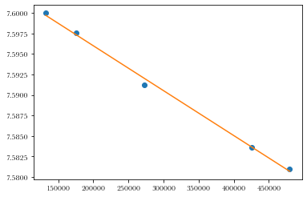

```python
def f(x,a,b): return a+b*x
popt_bid, _ = curve_fit(f, bid_side_acc_vols, bid_avg_price_per_share, p0=[1,1])

plt.plot(bid_side_acc_vols,bid_avg_price_per_share,'o')
plt.plot(bid_side_acc_vols,[f(i,*popt_bid) for i in bid_side_acc_vols])
print(popt_bid[-1])
```

#### To tackle this, we could reflect the graph at y-axis:

```
5.473885784597812e-08
```

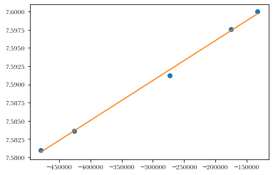

```python
bid_side_acc_vols_reflected = -bid_side_acc_vols[::-1]
bid_avg_price_per_share_reflected = bid_avg_price_per_share[::-1]

popt_bid_reflected, _ = curve_fit(f, bid_side_acc_vols_reflected, bid_avg_price_per_share_reflected, p0=[1,1])


plt.plot(bid_side_acc_vols_reflected,bid_avg_price_per_share_reflected,'o')
plt.plot(bid_side_acc_vols_reflected,[f(i,*popt_bid_reflected) for i in bid_side_acc_vols_reflected])
print(popt_bid_reflected[-1])
```

#### For the limit order book slope we merge all the points from both ask and bid side and again apply linear regression:

```
3.2660719861017266e-08
```

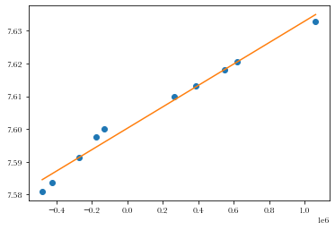

```python
ask_side_vols = get_vol(df,3,'ask')
ask_side_acc_vols = np.cumsum(ask_side_vols)
ask_side_prices = get_price(df,3,'ask')
ask_avg_price_per_share = [sum([i*k for i,k in zip(ask_side_prices[:m+1],ask_side_vols[:m+1])])/j \
                                               for m,j in enumerate(ask_side_acc_vols)]

order_acc_vols = list(bid_side_acc_vols_reflected) + list(ask_side_acc_vols)
order_avg_price_per_share = list(bid_avg_price_per_share_reflected) + list(ask_avg_price_per_share)

popt_order, _ = curve_fit(f, order_acc_vols, order_avg_price_per_share, p0=[1,1])

plt.plot(order_acc_vols,order_avg_price_per_share,'o')
plt.plot(order_acc_vols,[f(i,*popt_order) for i in order_acc_vols])
print(popt_order[-1])
```

#### Finally, all together:

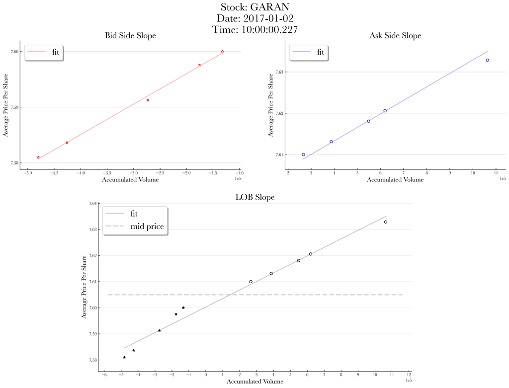

```python
plot_index(df,3,date,dpi=300)
```

#### Mind that these slopes are averaged over every minute as described earlier to get the desired result:

```python
get_significant_figures(results[results.columns[-3:]],2,0.001)
```

|  | Stock: GARAN Date: 2017-01-02 bid slope | Stock: GARAN Date: 2017-01-02 ask slope | Stock: GARAN Date: 2017-01-02 order slope |
| --- | --- | --- | --- |
| 10:00 | 2.33•E-8 | 24.64•E-9 | 2.37•E-8 |
| 10:01 | 1.98•E-8 | 20.74•E-9 | 2.22•E-8 |
| 10:02 | 19.87•E-9 | 1.88•E-8 | 21.07•E-9 |
| 10:03 | 18.46•E-9 | 17.32•E-9 | 19.08•E-9 |
| 10:04 | 19.46•E-9 | 15.85•E-9 | 18.18•E-9 |
| ... | ... | ... | ... |
| 17:58 | 5.49•E-9 | 6.71•E-9 | 5.85•E-9 |
| 17:59 | 5.68•E-9 | 6.69•E-9 | 5.96•E-9 |
| 18:05 | 8.26•E-9 | 7.73•E-9 | 5.21•E-9 |
| 18:08 | 9.33•E-9 | 0.94•E-8 | 8.48•E-9 |
| 18:09 | 9.35•E-9 | 9.36•E-9 | 8.46•E-9 |

421 rows × 3 columns

[Next notebook: Data Preparation](https://quantumyilmaz.github.io/SPHS20/data_prep.html)